# Untitled

## Multivariate Analysis

Heat Maps

What Countries are driving the global emissions for each continent?

Europe

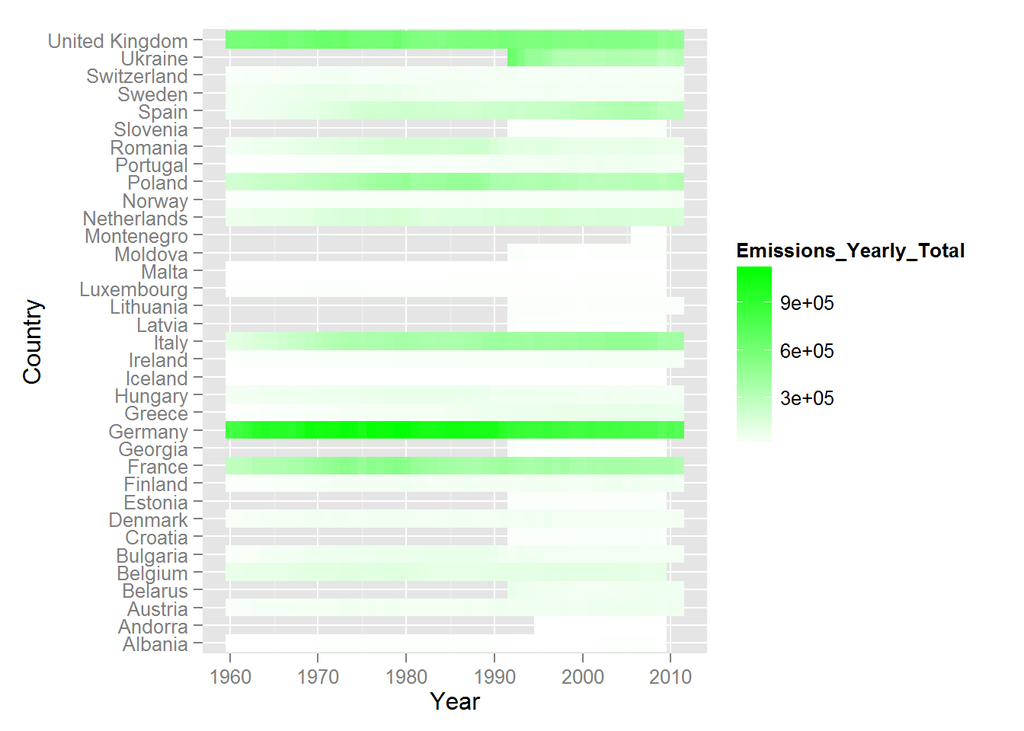

Asia

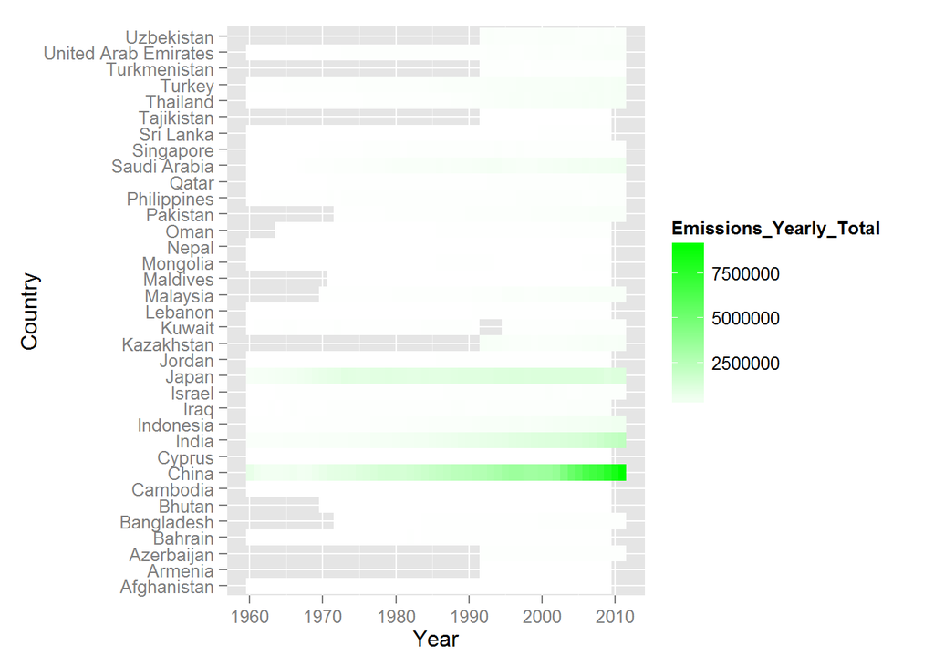

Africa

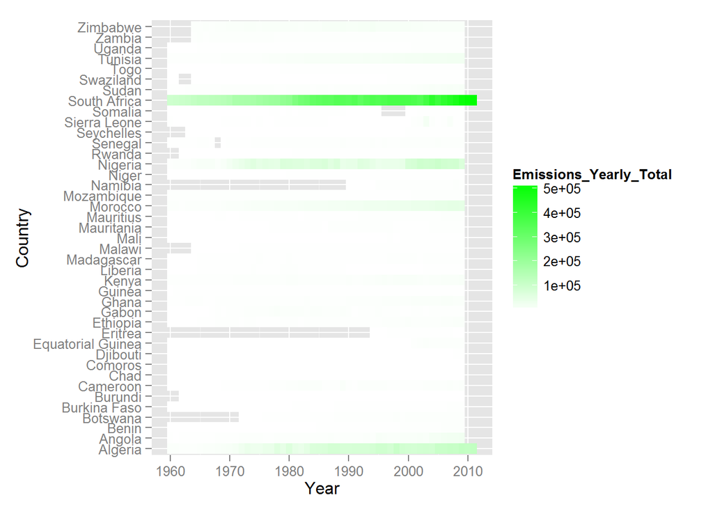

S. America

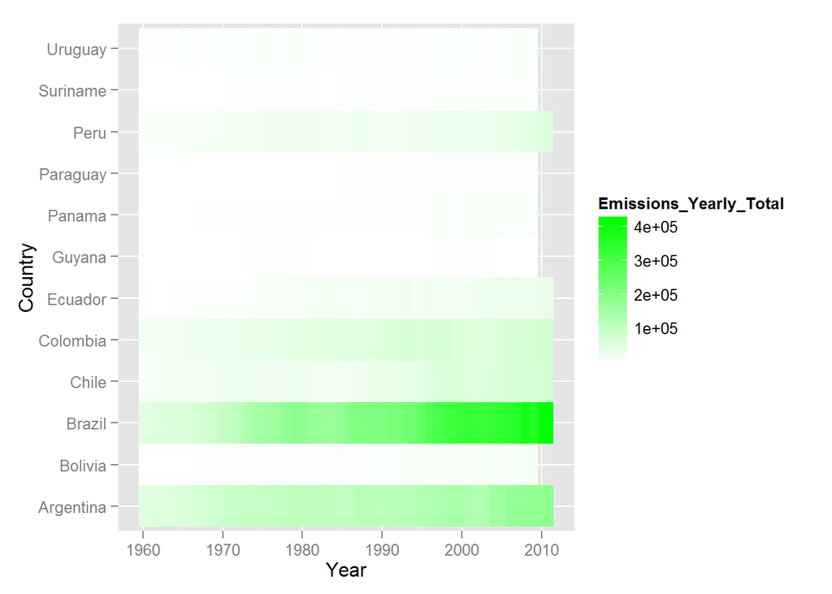

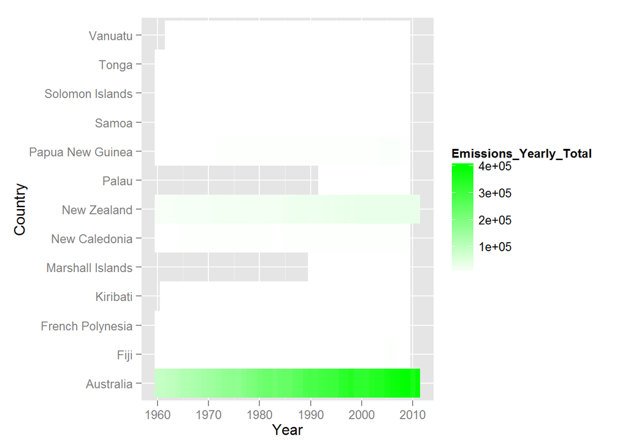

N.America

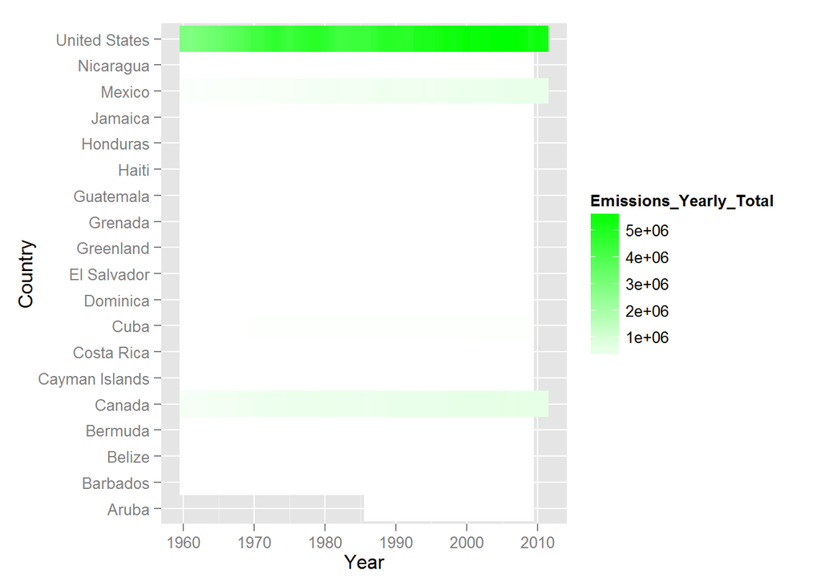

Thanks to the heat maps, we can see what countries in each continent contribute the most to the continent’s emissions.

In this section, we can explore multiple features in earlier plots

Looking at the emissions by populations scatterplot but coloured by continents.

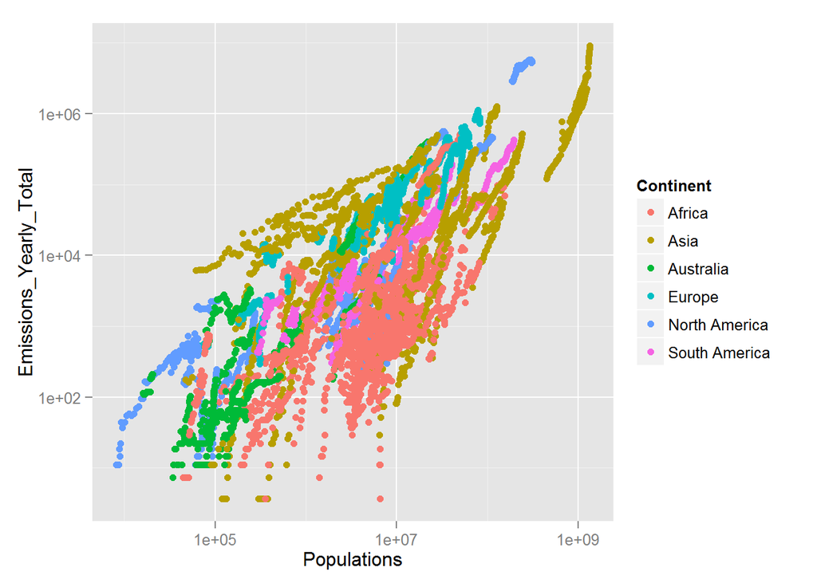

```
##
##  Pearson's product-moment correlation
##
## data:  Populations and Emissions_Yearly_Total
## t = 61.936, df = 7042, p-value < 2.2e-16
## alternative hypothesis: true correlation is not equal to 0
## 95 percent confidence interval:
##  0.5785058 0.6087478
## sample estimates:
##       cor
## 0.5938365
```

As expected, Africa seems to be at the bottom with Asia being very spread out.

Are global emissions yearly and capita increasing over the years for every continent?

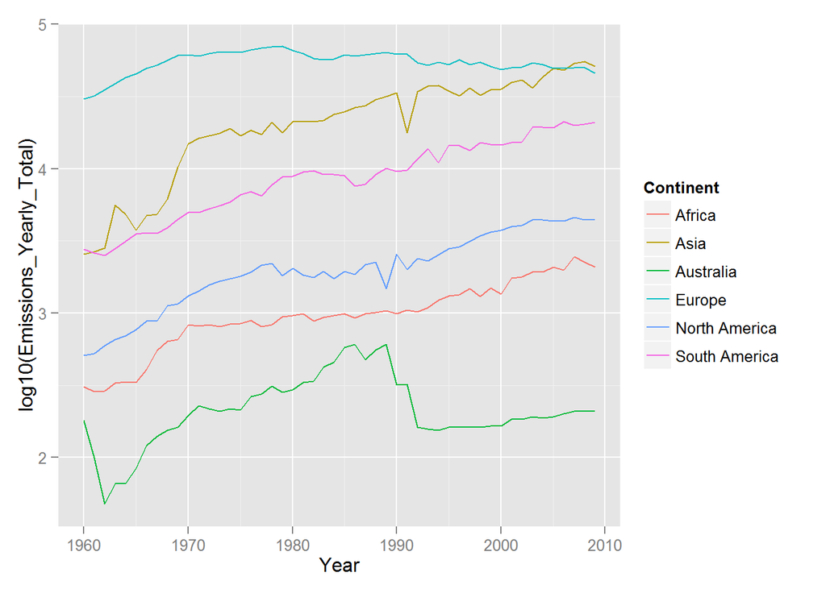

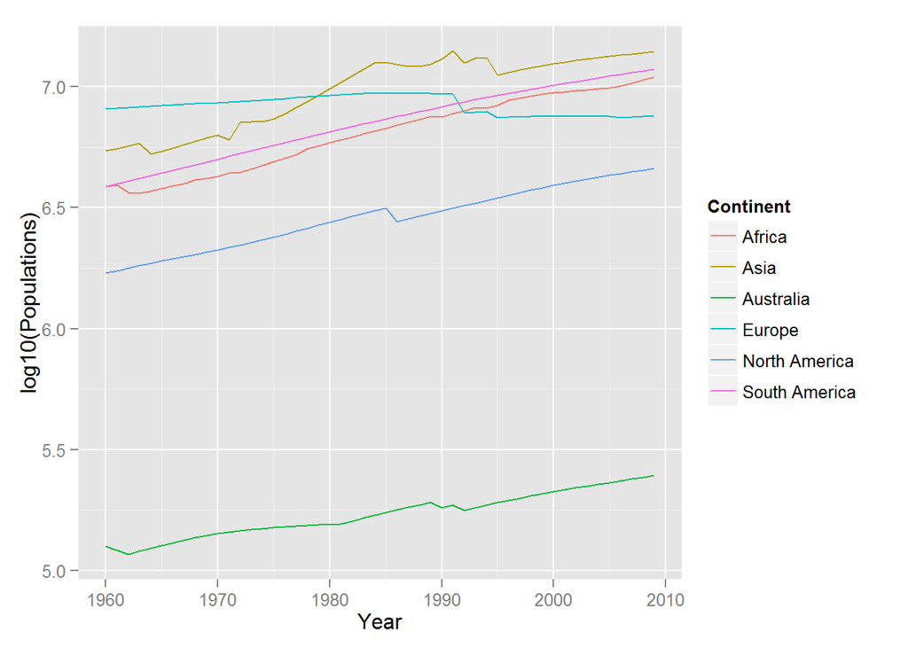

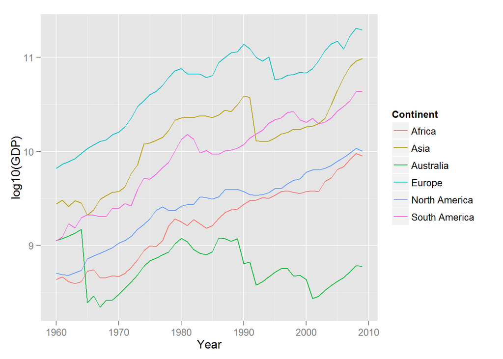

GDP also shows a steady rise excepting the dips in 1980-83, 1990-93, 1998, 2001-02, and 2008-09 which corresponds to all the years there was a global recession. We have seen from an earlier scatterplot that GDP is positively correlated with Emissions. While this doesn’t mean a causation, it makes sense that a country would emit more the higher the GDP as one contributor to a rising GDP is a country becoming more industrialized, another cause is more trade which also means more production and therefore, more emission.

Looking at the Emissions per Capita

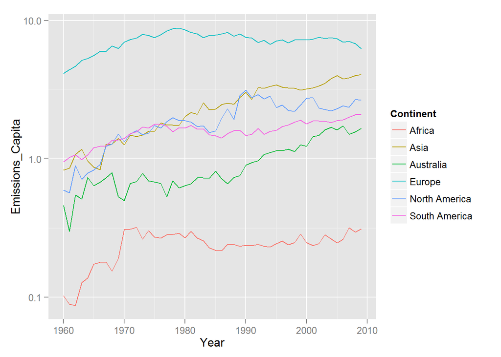

How do the emissions features by energy use, access to electricity and literacy rate vary by continent?

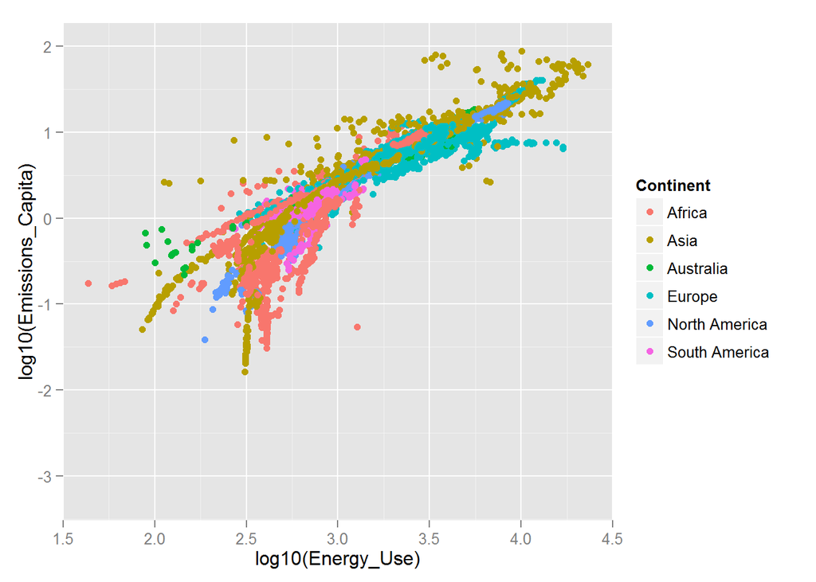

```
##
##  Pearson's product-moment correlation
##
## data:  log10(Energy_Use) and log10(Emissions_Capita)
## t = 142.94, df = 4336, p-value < 2.2e-16
## alternative hypothesis: true correlation is not equal to 0
## 95 percent confidence interval:
##  0.9029092 0.9133361
## sample estimates:
##       cor
## 0.9082636
```

There does seem to be a strong positive correlation between energy use and emissons per capita, energy use is the average energy use per capita for a country and since emissions per capita is the emissions per person, it makes sense there should be a correlation between both, splitting it up by continent also shows a pattern, most of Africa along with some Asian countries are populated on the lower left implying a low energy use and emissions per capita, as expected, Europe, America and some of Asia occupies the top right part of the scatterplot. Below is the correlation score.

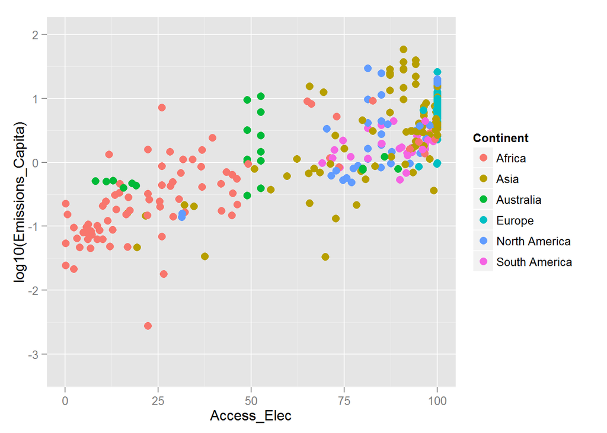

```
##
##  Pearson's product-moment correlation
##
## data:  Access_Elec and log10(Emissions_Capita)
## t = 24.975, df = 343, p-value < 2.2e-16
## alternative hypothesis: true correlation is not equal to 0
## 95 percent confidence interval:
##  0.7623081 0.8377763
## sample estimates:
##       cor
## 0.8032425
```

The access to electricity rate measures the percentage of a country with access to electricity, there is also a positive correlation here and it shows the countries with the most access also seem to be the worst offenders.

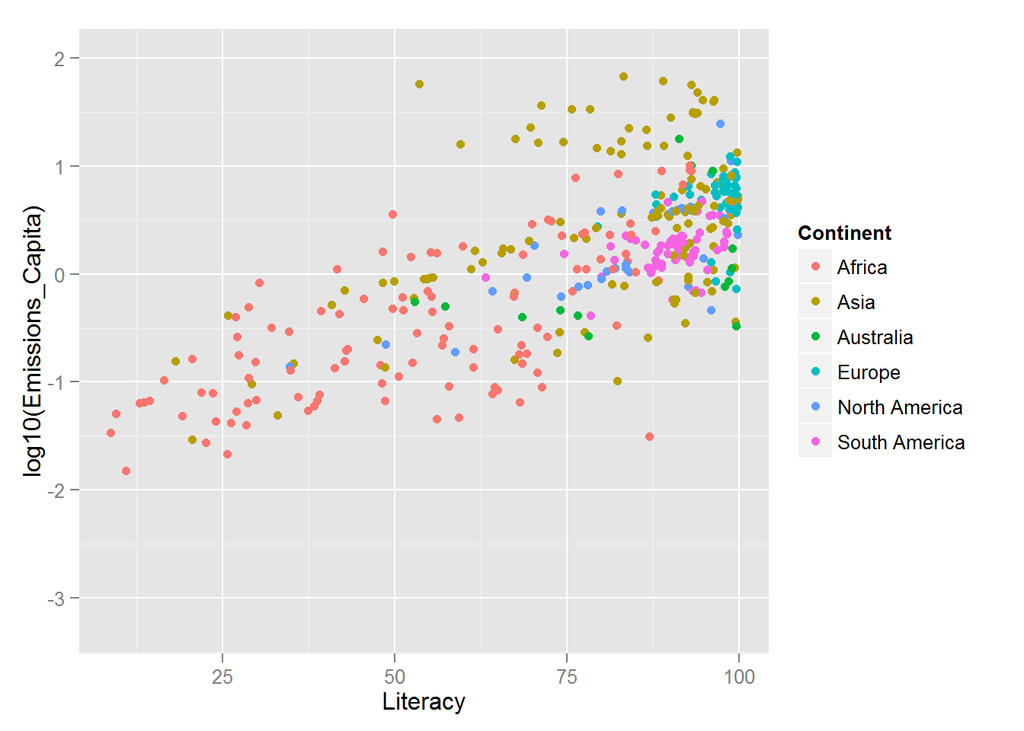

```
##
##  Pearson's product-moment correlation
##
## data:  Literacy and log10(Emissions_Capita)
## t = 19.54, df = 390, p-value < 2.2e-16
## alternative hypothesis: true correlation is not equal to 0
## 95 percent confidence interval:
##  0.6495477 0.7501352
## sample estimates:
##       cor
## 0.7033452
```

Literacy rate measures the rate of adults aged 15 & over that are literate for each country, the scatterplot of Literacy to emissions capita shows a similar pattern as energy use to emissions capita with a similar distribution and a correlation score of 0.7.

Showing the GDP by Emissions yearly plot by continent…

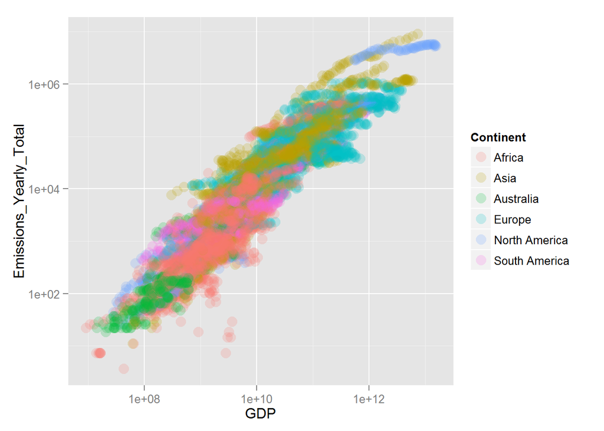

```
##
##  Pearson's product-moment correlation
##
## data:  GDP and Emissions_Yearly_Total
## t = 93.493, df = 6225, p-value < 2.2e-16
## alternative hypothesis: true correlation is not equal to 0
## 95 percent confidence interval:
##  0.7537035 0.7743738
## sample estimates:
##       cor
## 0.7642348
```

GDP by Emissions yearly also shows a very strong positive correlation, with the same above mentioned patterns, the ony difference is some countries in the continent of Australia show an even lower GDP and yearly emission than countries in Africa, this makes sense since some of those countries are very small countries. The top right part of the plot follows the usual trend of some Asian countries, Europe and North America having both a high GDP and yearly emissions.

We can see pattern emerging in pretty much all the plots colored with continents.

The plan is now to setup a linear model individually for both emissions per capita and emissions yearly variables. For the emissions per capita variable, the features to use are Year, Literacy, Energy Use, Access to electricity and Continent, and for the emissions yearly, Year, Continent, GDP and Population.

```
##
## Calls:
## yr1: lm(formula = I(log(Emissions_Yearly_Total)) ~ I(log(Populations)),
##     data = df)
## yr2: lm(formula = I(log(Emissions_Yearly_Total)) ~ I(log(Populations)) +
##     Year, data = df)
## yr3: lm(formula = I(log(Emissions_Yearly_Total)) ~ I(log(Populations)) +
##     Year + I(log10(GDP)), data = df)
## yr4: lm(formula = I(log(Emissions_Yearly_Total)) ~ I(log(Populations)) +
##     Year + I(log10(GDP)) + Continent, data = df)
##
## ============================================================================
##                                     yr1        yr2        yr3        yr4
## ----------------------------------------------------------------------------
## (Intercept)                      -6.159***  -52.647*** 49.968***  43.543***
##                                  (0.157)     (2.891)   (1.672)    (1.647)
## I(log(Populations))               0.971***    0.951***  0.037***   0.087***
##                                  (0.010)     (0.010)   (0.008)    (0.010)
## Year                                          0.024*** -0.033***  -0.029***
##                                              (0.001)   (0.001)    (0.001)
## I(log10(GDP))                                           2.358***   2.156***
##                                                        (0.017)    (0.021)
## Continent: Asia/Africa                                             0.865***
##                                                                   (0.032)
## Continent: Australia/Africa                                        0.311***
##                                                                   (0.045)
## Continent: Europe/Africa                                           0.587***
##                                                                   (0.039)
## Continent: North America/Africa                                    0.435***
##                                                                   (0.038)
## Continent: South America/Africa                                    0.606***
##                                                                   (0.040)
## ----------------------------------------------------------------------------
## R-squared                             0.564      0.580     0.897      0.908
## adj. R-squared                        0.564      0.579     0.896      0.908
## sigma                                 1.816      1.784     0.852      0.804
## F                                  9110.755   4852.124 17969.998   7678.279
## p                                     0.000      0.000     0.000      0.000
## Log-likelihood                   -14198.098 -14070.722 -7839.731  -7470.758
## Deviance                          23232.666  22407.449  4522.196   4016.819
## AIC                               28402.197  28149.444 15689.461  14961.517
## BIC                               28422.777  28176.884 15723.145  15028.883
## N                                  7044       7044      6227       6227
## ============================================================================
```

```
##
## Calls:
## cap1: lm(formula = I(log10(Emissions_Capita)) ~ Year, data = df)
## cap2: lm(formula = I(log10(Emissions_Capita)) ~ Year + Literacy, data = df)
## cap3: lm(formula = I(log10(Emissions_Capita)) ~ Year + Literacy + I(log10(Energy_Use)),
##     data = df)
## cap4: lm(formula = I(log10(Emissions_Capita)) ~ Year + Literacy + I(log10(Energy_Use)) +
##     Access_Elec, data = df)
## cap5: lm(formula = I(log10(Emissions_Capita)) ~ Year + Literacy + I(log10(Energy_Use)) +
##     Access_Elec + Continent, data = df)
##
## =======================================================================================
##                                     cap1       cap2       cap3       cap4       cap5
## ---------------------------------------------------------------------------------------
## (Intercept)                      -19.176***  8.399      5.536*    11.342     12.309
##                                   (1.253)   (5.318)    (2.813)    (7.655)    (7.869)
## Year                               0.010*** -0.005     -0.005**   -0.008     -0.008*
##                                   (0.001)   (0.003)    (0.001)    (0.004)    (0.004)
## Literacy                                     0.023***   0.007***  -0.000      0.001
##                                             (0.001)    (0.001)    (0.003)    (0.003)
## I(log10(Energy_Use))                                    1.147***   1.116***   1.126***
##                                                        (0.036)    (0.079)    (0.083)
## Access_Elec                                                        0.008***   0.009***
##                                                                   (0.001)    (0.002)
## Continent: Asia/Africa                                                       -0.059
##                                                                              (0.113)
## Continent: Europe/Africa                                                     -0.251
##                                                                              (0.154)
## Continent: North America/Africa                                              -0.108
##                                                                              (0.146)
## Continent: South America/Africa                                              -0.083
##                                                                              (0.127)
## ---------------------------------------------------------------------------------------
## R-squared                            0.033      0.499     0.852      0.901      0.911
## adj. R-squared                       0.032      0.497     0.851      0.892      0.892
## sigma                                0.775      0.518     0.241      0.174      0.173
## F                                  237.452    193.884   610.731     95.869     48.507
## p                                    0.000      0.000     0.000      0.000      0.000
## Log-likelihood                   -8198.556   -297.086     3.618     18.254     20.638
## Deviance                          4229.618    104.494    18.434      1.266      1.143
## AIC                              16403.111    602.171     2.764    -24.508    -21.276
## BIC                              16423.691    618.056    21.637    -13.407     -2.775
## N                                 7044        392       322         47         47
## =======================================================================================
```

I will use Russia as a test case since Russia isn’t included in the dataset. Looking through databank’s website, I see Russia has the following information for the year 2010, Emissions - 1,740,776kt, 12.2Metric tons per capita, population - 142385523, GDP - 1524916112078.9, Literacy rate and Access to Electricity rate at 100% and Energy used is 4932kg of oil equivalent per capita. Splitting these into two seperate datasets so as to test for both emissions yearly and Emissions per capita in the model.

```
##        fit      lwr     upr
## 1 791479.4 163544.2 3830398
```

```
##        fit      lwr      upr
## 1 2.638894 1.770455 3.933318
```

Results The Emissions Capita model prediction for Russia for the 2010 is 13.99 within a confidence interval of 0.95. The actual emissions of 12.2 Metric tons falls within this range.

Russia’s 2010 emission was 1,740,776kilotonnes, the model fit predicted 791479.4 which is about a million Kilotonnes less than the actual, though it falls within the lower and upper bound predicted by the model.

# Final Plots and Summary

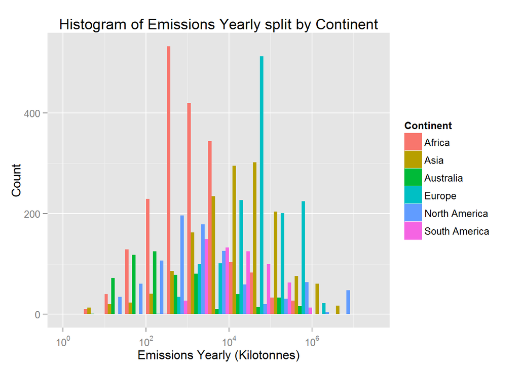

This first plot I chose because I feel like it shows the distributions of emissions yearly contribution by each continent. The plot also shows how variable each of the continents are, for example, Asia holds the most number of people of all the continents and it’s emissions is also very diverse and variable, Asia of all the continents holds a diverse range countries, from contributing lowly to emissions to medium to contributing a lot, also noticeable is that Asia by itself, is normally distriuted. Other continents while also variable are not to that extent, Africa mostly contains continents on the lower end to medium, North America and Europe along with some Asia (most likely China) dominates the higher end with everybody else in the lower to upper middle.

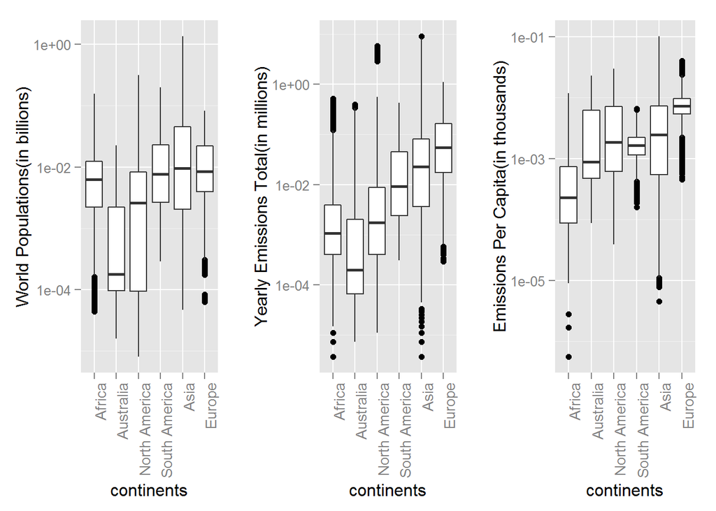

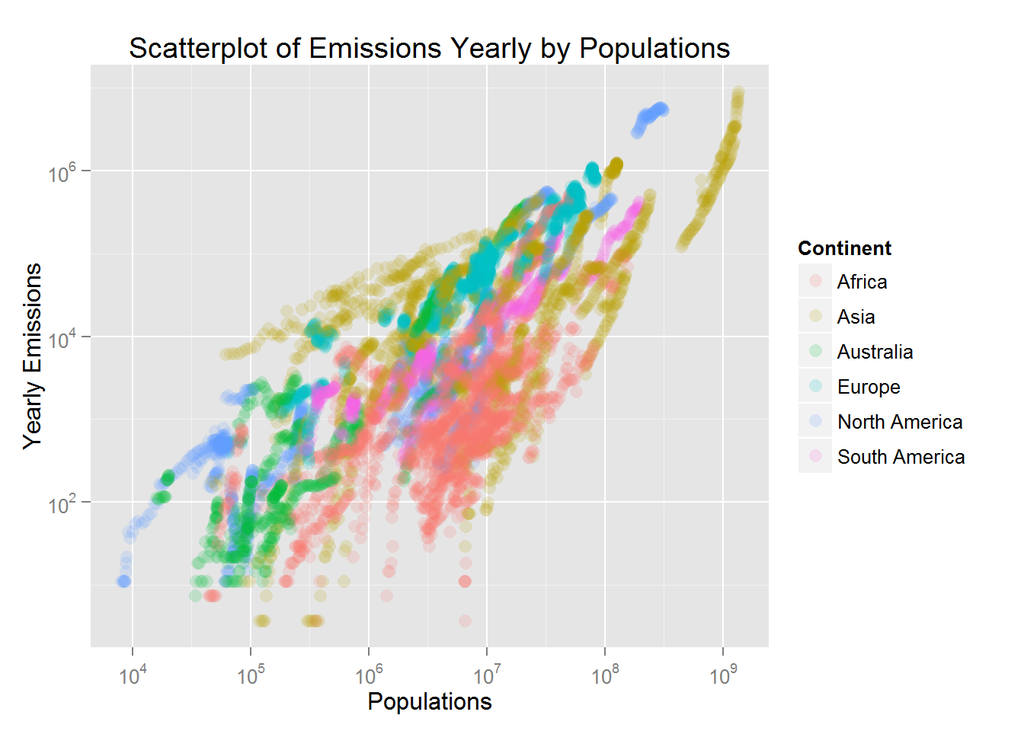

The final plot shows the positive linear relationship between world population and yearly emissions. This makes sense since the more people there are, the more emissions likely would be generated. The reason for this plot is to visualize the three variables Continents, Yearly emissios and populations relative to each other. This plot shows a poitive strong correlation between populations and emissions yearly, it also shows the same movement for continents, so not only are the populations for each continent rising, the emissions for each continent is also rising. The continents are emitting more just as their populations are growing

# Reflections

This has been an interesting dataset to work on, problems encountered are mostly related to wrangling the data and merging the individual datasets. The features were chosen intuitively, most worked well and revealed insightful information but some weren’t so fruitful.

There were a number of very interesting correlations from the start with the scatterplot matrix, although emissions yearly is highly correlated individually with both GDP and Populations, GDP and Populations aren’t necessarily strongly correlated. This makes sense since a rising population will or at least should contribute to rising emissions and also rising GDP implies a growing economy which also should contribute to rising emissions but a growing population won’t necessarily by itself strongly drive the GDP of a country.

Another interesting pair of variables are the emissions per capita and Energy use. Energy use isn’t necessarily highly correlated with emissions yearly but it is highly correlated with emissions per capita. This makes sense since both emissions per capita and Energy use are per capita, it is intuitive that the amount of energy used per person would be positively correlated with the amount of carbon emitted per person.

The correlation between Literacy rate and access to electricity is possibly due to the fact that individuals in more developed countries would have more access to electricity as well as education, I thought it’d be interesting to add country’s literacy rate to this dataset so as to compare what correlation it has to emission, it made sense to compare this to emissions per capita since the literacy measures the rate for 15s & over for a country’s population. While this might seem counter intuitive at first, it actually makes sense since more developed countries would have a higher literacy rate and also a high rate of emission. The reason I say this seemed counter intuitive at fist is because I chose to add this feature hoping I’d find a negative correlation implying that a higher literacy rate would mean a higher chance of awareness and education on global warming hence, lower emissions, while this is likely true, more awareness wouldn’t necessarily translate to taking steps towards improving the situation. Besides, countries with low emissions aren’t necessarily doing so because of awareness or education, they usually are because they’re just not capable of burning that much carbon based fuel due to development. So it is possible for a higher literacy rate to mean lower emissions, it would however only mean lower emissions among countries with an already high emission and not compared to countries already with a low emission rate.

Jumping forward to the linear model built, since I chose two features of interest, I decided to build a different model for each, this was in part drived by finding different variables correlating with each of the features of interest. Russia was chosen as the test case because Russia is not in the dataset and I was able to find all the relevant data for Russia to test with. Both Correlation scores are looking pretty good, included in the mtable are coefficients and correlation scores for both. Both are over 0.9.

I definitely will keep working on this dataset as there are many more opportunities for finding interesting things from it, one thing I’d like to look into in the future would be predicting what the global emissions would be like in the future and to look more into maybe comparing this dataset with a dataset if possible of natural disasters and to see if there might be a correlation between both.